# PyBSASeq Analysis Report

This report summarizes the results of the PyBSASeq analysis for Bulk Segregant Analysis (BSA) to identify trait-associated structural variants (SVs). Each section describes an output file, its biological insights, and includes relevant visualizations.

## 1. SV Analysis (sv_fagz.csv)

**Description:** The `sv_fagz.csv` file contains filtered structural variants (SVs) with their associated metrics, including Fisher's exact test P-values (FE_P), G-statistics (G_S), and Δ(allele frequency). This file represents the core dataset after filtering out low-quality or uninformative SVs.

**Biological Insights:**

- **Trait Association:** SVs with low FE_P values (e.g., < 0.01) indicate significant differences in allele frequencies between bulks, suggesting potential association with the trait of interest. These SVs are candidates for further investigation as they may be linked to quantitative trait loci (QTLs).
- **G-statistic:** High G-statistic values reflect strong deviations from expected allele frequencies under the null hypothesis, pointing to regions of the genome where selection pressures may have acted.
- **Δ(Allele Frequency):** Large absolute Δ(AF) values indicate differential selection between bulks, which can help pinpoint genomic regions harboring trait-associated variants.

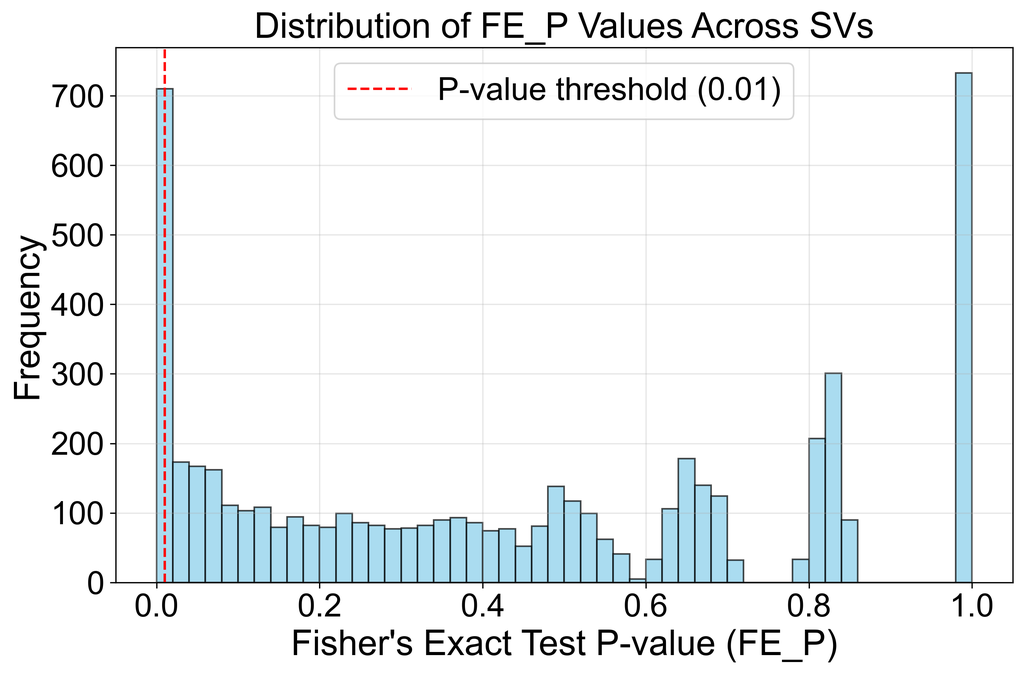

Histogram of Fisher's Exact Test P-values across SVs, highlighting significant SVs below the threshold.

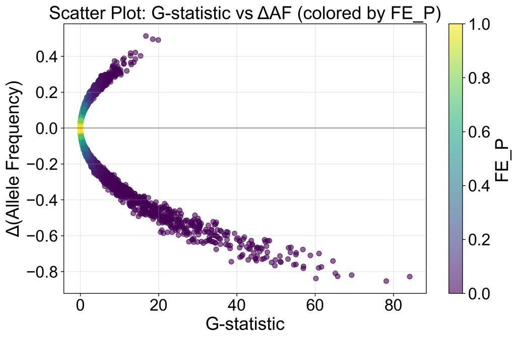

Scatter plot of G-statistic vs Δ(Allele Frequency), colored by FE_P, showing the relationship between statistical significance and allele frequency differences.

## 2. High FE_P SVs (sv_fagz_fep.csv)

**Description:** The `sv_fagz_fep.csv` file contains SVs with high Fisher's exact test P-values (FE_P > 0.8), indicating SVs that are not significantly associated with the trait based on allele frequency differences.

**Biological Insights:**

- **Non-significant SVs:** These SVs are unlikely to be associated with the trait, as their allele frequencies do not differ significantly between bulks. They may represent neutral genetic variation or sequencing artifacts.
- **Background Variation:** Understanding the distribution of non-significant SVs helps establish a baseline for neutral genetic variation, aiding in the identification of truly significant SVs.

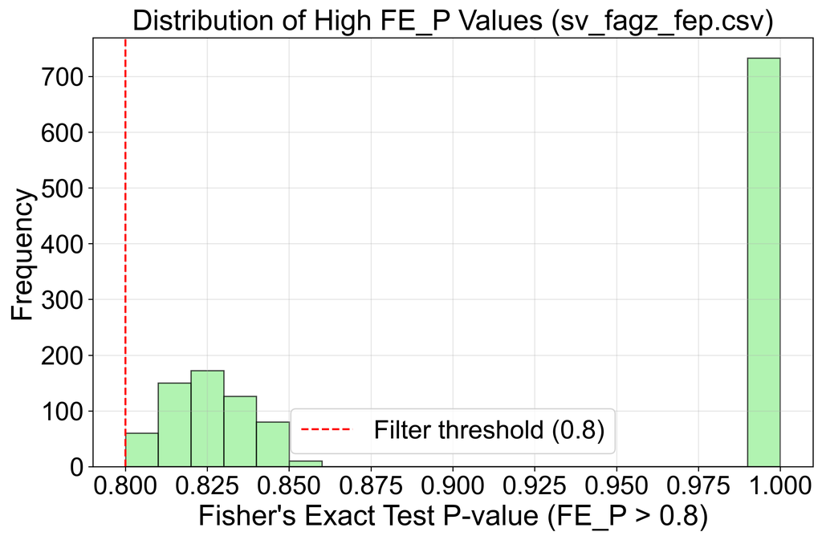

Histogram of high FE_P values (> 0.8), showing the distribution of non-significant SVs.

## 3. Sliding Windows Analysis (sliding_windows.csv)

**Description:** The `sliding_windows.csv` file contains metrics for sliding windows across the genome, including smoothed sSV/totalSV ratios, G-statistics, and Δ(allele frequency). This file aggregates SV data into genomic windows for regional analysis.

**Biological Insights:**

- **Genomic Regions of Interest:** High sSV/totalSV ratios in specific windows indicate regions enriched for significant SVs, likely harboring QTLs associated with the trait.
- **Smoothed Trends:** Smoothing reveals broader genomic patterns, reducing noise and highlighting consistent signals of trait association across windows.
- **Comparative Analysis:** Comparing sSV/totalSV ratios across chromosomes helps prioritize regions for further genetic mapping or functional studies.

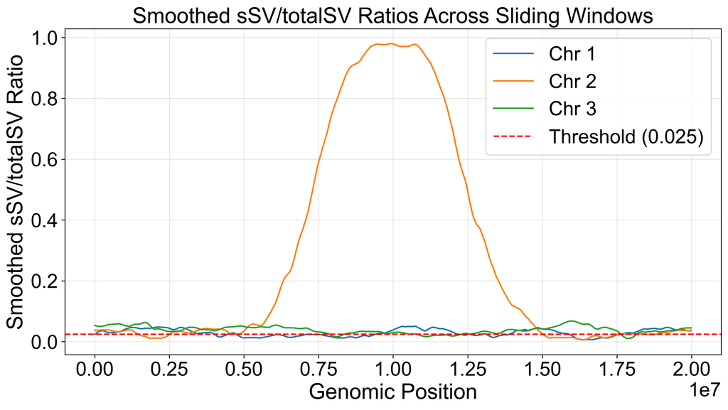

Line plot of smoothed sSV/totalSV ratios across sliding windows, highlighting regions above the threshold.

## 4. ΔSNP Index Analysis (sliding_windows.csv)

**Description:** The ΔSNP index, represented as `smthedDAF` in `sliding_windows.csv`, quantifies the difference in allele frequencies (Δ(AF)) between bulks across sliding windows. This metric highlights genomic regions with significant allele frequency divergence, indicative of trait-associated variants.

**Biological Insights:**

- **Trait Association:** Large absolute ΔSNP index values (positive or negative) indicate regions where allele frequencies differ significantly between bulks, suggesting the presence of quantitative trait loci (QTLs) linked to the trait of interest.
- **Directionality:** In cases with two bulks or a reference parent, positive and negative ΔSNP index values can indicate which bulk or parental allele is enriched, providing insights into the genetic basis of the trait (e.g., dominant or recessive inheritance).
- **Genomic Mapping:** Regions where the ΔSNP index exceeds thresholds (e.g., `thrshld_af_abs` or `thrshld_af_n/p`) are prime candidates for fine mapping or functional genomics to identify causal variants or genes.
- **Smoothed Data:** The smoothed ΔSNP index reduces noise, making it easier to identify consistent patterns of allele frequency divergence across larger genomic regions.

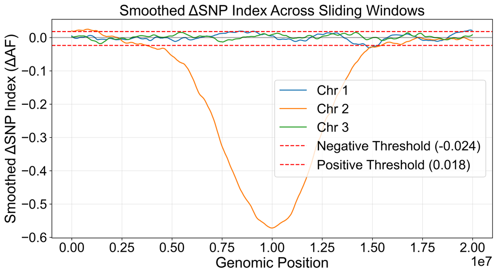

Line plot of smoothed ΔSNP index (Δ(AF)) across sliding windows, with thresholds indicating significant regions of allele frequency divergence.

## 5. Significant SV Regions (sv_region.csv)

**Description:** The `sv_region.csv` file lists genomic regions with significant SVs, defined by sSV/totalSV ratios above the threshold, including chromosome, start/end positions, peaks, and number of sliding windows.

**Biological Insights:**

- **QTL Identification:** These regions are prime candidates for containing QTLs, as they show significant enrichment of trait-associated SVs.
- **Region Size and Strength:** The number of sliding windows (NumOfSWs) indicates the size and robustness of the significant region, with larger regions suggesting stronger or broader trait associations.
- **Targeted Follow-up:** These regions can guide targeted sequencing or functional genomics studies to identify causal genes or variants.

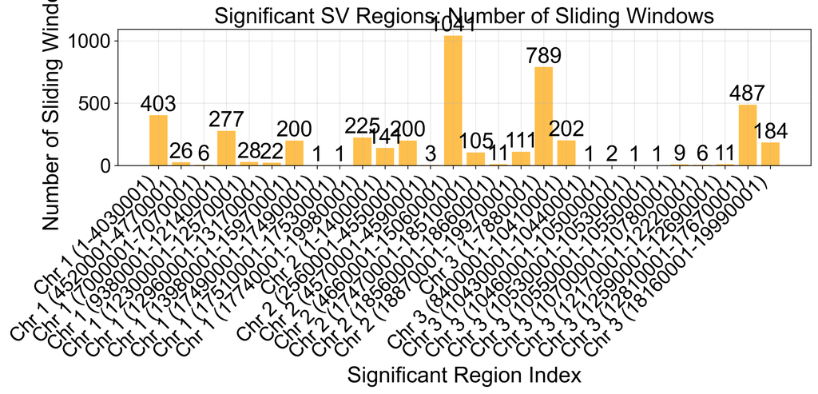

Bar plot showing the number of sliding windows in significant SV regions, indicating the extent of trait-associated genomic regions.

## 6. Chromosome SV Summary (num_sv_on_chr_file.csv)

**Description:** The `num_sv_on_chr_file.csv` file summarizes the number of significant SVs (sSVs), total SVs, and their ratio per chromosome.

**Biological Insights:**

- **Chromosome Contribution:** Chromosomes with high sSV/totalSV ratios are more likely to harbor trait-associated variants, guiding prioritization for further analysis.
- **Genomic Distribution:** Comparing sSV and total SV counts across chromosomes reveals the distribution of genetic variation and trait-associated signals.
- **Resource Allocation:** Chromosomes with low sSV counts may be deprioritized, focusing research efforts on high-signal chromosomes.

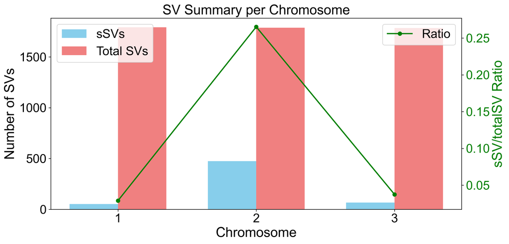

Bar plot comparing sSVs and total SVs per chromosome, with sSV/totalSV ratio overlaid.

## 7. Miscellaneous Information (misc_info.csv)

**Description:** The `misc_info.csv` file contains metadata such as chromosome IDs, SV counts, average locus depths, running time, and genome-wide thresholds.

**Biological Insights:**

- **Analysis Quality:** Average locus depths indicate sequencing coverage, with higher depths suggesting more reliable SV calls.
- **Thresholds:** Genome-wide thresholds (e.g., sSV/totalSV, G-statistic, Δ(AF)) provide context for interpreting significance, ensuring robust identification of trait-associated regions.
- **Efficiency:** Running time helps assess computational efficiency, which is critical for large datasets or iterative analyses.

## 8. Warning Log (wrnLog.csv)

**Description:** The `wrnLog.csv` file logs warnings generated during analysis, such as empty sliding windows or invalid chromosome names.

**Biological Insights:**

- **Data Quality:** Frequent warnings (e.g., empty sliding windows) may indicate low SV density in certain regions, potentially due to sequencing gaps or low genetic variation.
- **Analysis Robustness:** Addressing warnings (e.g., by adjusting sliding window parameters) can improve the reliability of detected trait associations.

## 9. Peak Significance (BSASeq.csv)

**Description:** The `BSASeq.csv` file contains verified peaks of significant SV regions, with metrics such as sSV/totalSV ratio, G-statistic, Δ(AF), and statistical significance (e.g., t-test p-values).

**Biological Insights:**

- **Significant Peaks:** Peaks with significant sSV/totalSV, G-statistic, or Δ(AF) values are strong candidates for QTLs, warranting further genetic or functional validation.
- **Statistical Confidence:** Significance indicators (e.g., Significance_SSV, Significance_TT) provide confidence in the trait association, with multiple significant metrics reinforcing the likelihood of true positives.
- **Prioritization:** Peaks with high significance across multiple metrics should be prioritized for downstream analyses, such as fine mapping or gene identification.

## Conclusion

This analysis has identified significant SVs and genomic regions potentially associated with the trait of interest. The ΔSNP index plot highlights regions with significant allele frequency differences, complementing the sSV/totalSV and G-statistic analyses. The results provide a foundation for further genetic mapping, functional studies, or breeding applications. Review the significant regions in `sv_region.csv` and `BSASeq.csv` for prioritized targets, and consider re-running the analysis with refined regions (using the `--region` option) to verify additional peaks or valleys.